# log_analysis_with_MI_smcfcs

## Ingroup Identification

> > Exploratory Research Question 1: Is there a three-way interaction between in-group identification, framing condition, and norm-intervention condition?

Is the difference between Control Norm and Other Norm different for people low vs high on ingroup identification? Does this vary across framing conditions?

### Visualization

```r
text_settings <- theme(text = element_text(size = 20)) +
  theme(plot.title = element_text(size = 20, face = 'bold')) +
  theme(axis.title.x = element_text(face = 'bold')) +
  theme(axis.title.y = element_text(face = 'bold')) +
  theme(axis.text.x = element_text(size = 14)) +
  theme(axis.text.y = element_text(size = 20)) +
  theme(axis.ticks = element_blank())
```

#### Ingroup x Framing

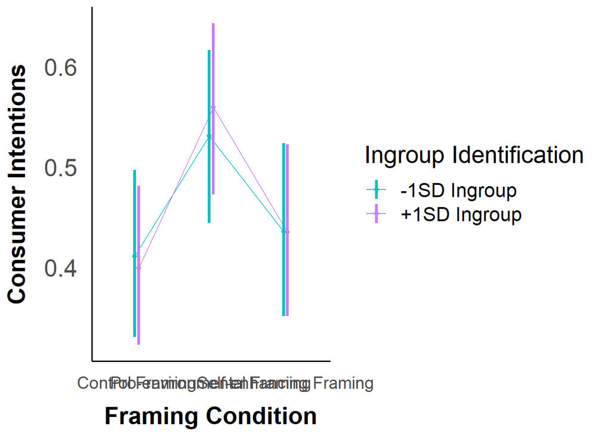

```r
sd_below <- mean(average_df$ingroup_center) - sd(average_df$ingroup_center)
sd_above <- mean(average_df$ingroup_center) + sd(average_df$ingroup_center)

at_list <- list(ingroup_center = c(sd_below, sd_above))

emmip(log_mice, ingroup_center ~ framing_condition, CIs = TRUE, type = "response", CIarg = list(lwd = 1.2, alpha = 1), xlab = "Framing Condition", ylab = "Consumer Intentions", at = at_list) +
  scale_x_discrete(breaks=c("control_framing","pro_env_framing", "self_enh_framing"), labels = c("Control Framing", "Pro-environmental Framing", "Self-enhancing Framing")) +
  theme_apa() +
  text_settings +
  scale_color_manual(name = "Ingroup Identification", breaks = c(-1.01218644014995, 1.01218644014995), labels = c("-1SD Ingroup", "+1SD Ingroup"), values = c("#00BFC4","#C77CFF"))
```

#### Ingroup x Norm

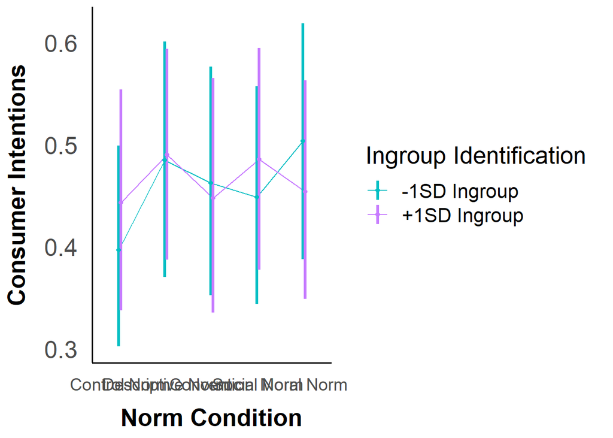

```r
emmip(log_mice, ingroup_center ~ norm_condition, CIs = TRUE, type = "response", CIarg = list(lwd = 1.2, alpha = 1), xlab = "Norm Condition", ylab = "Consumer Intentions", at = at_list) +
  scale_x_discrete(breaks=c("control_norm","descriptive_norm", "convention_norm", "social_norm", "moral_norm"), labels = c("Control Norm", "Descriptive Norm", "Convention", "Social Norm", "Moral Norm")) +
  theme_apa() +
  text_settings +
  scale_color_manual(name = "Ingroup Identification", breaks = c(-1.01218644014995, 1.01218644014995), labels = c("-1SD Ingroup", "+1SD Ingroup"), values = c("#00BFC4","#C77CFF"))
```

#### Ingroup, Norm, Framing

[figure not shown]

```r
emmip(log_mice, ingroup_center ~ norm_condition | framing_condition, type = "response", CIs = TRUE, CIarg = list(lwd = 1.2, alpha = 1), xlab = "Norm Condition", ylab = "Consumer Intentions", at = at_list) +
  scale_x_discrete(breaks=c("control_norm","descriptive_norm", "convention_norm", "social_norm", "moral_norm"), labels = c("Control", "Descriptive", "Convention", "Social", "Moral")) +
  facet_wrap(~framing_condition, labeller = labeller(framing_condition = frame_labs)) +
  theme_apa() +
  text_settings +
  scale_color_manual(name = "Ingroup Identification", breaks = c(-1.01218644014995, 1.01218644014995), labels = c("-1SD Ingroup", "+1SD Ingroup"), values = c("#00BFC4","#C77CFF"))
```

### Planned Comparisons

#### Storing low (-1SD) and high (+1SD) ingroup identification

```r
sd_below <- mean(average_df$ingroup_center) - sd(average_df$ingroup_center)
sd_above <- mean(average_df$ingroup_center) + sd(average_df$ingroup_center)
```

#### Calculate EM Means at low and high bio

```r
atlist <- list(ingroup_center = c(sd_below, sd_above))

combinations <- emmeans(log_mice, ~ norm_condition*ingroup_center*framing_condition, at=atlist, type = "response")

combinations %>% knitr::kable(digits = 2)
```

| norm_condition | ingroup_center | framing_condition | prob | SE | df | asymp.LCL | asymp.UCL |
| --- | --- | --- | --- | --- | --- | --- | --- |
| control_norm | -1.01 | control_framing | 0.39 | 0.08 | Inf | 0.25 | 0.56 |
| descriptive_norm | -1.01 | control_framing | 0.32 | 0.10 | Inf | 0.16 | 0.54 |
| convention_norm | -1.01 | control_framing | 0.52 | 0.10 | Inf | 0.33 | 0.71 |
| social_norm | -1.01 | control_framing | 0.37 | 0.07 | Inf | 0.25 | 0.52 |
| moral_norm | -1.01 | control_framing | 0.45 | 0.11 | Inf | 0.26 | 0.66 |
| control_norm | 1.01 | control_framing | 0.52 | 0.09 | Inf | 0.34 | 0.69 |
| descriptive_norm | 1.01 | control_framing | 0.39 | 0.09 | Inf | 0.23 | 0.57 |
| convention_norm | 1.01 | control_framing | 0.34 | 0.09 | Inf | 0.19 | 0.54 |
| social_norm | 1.01 | control_framing | 0.36 | 0.08 | Inf | 0.22 | 0.53 |
| moral_norm | 1.01 | control_framing | 0.39 | 0.09 | Inf | 0.24 | 0.57 |
| control_norm | -1.01 | pro_env_framing | 0.46 | 0.09 | Inf | 0.29 | 0.64 |
| descriptive_norm | -1.01 | pro_env_framing | 0.62 | 0.10 | Inf | 0.42 | 0.79 |
| convention_norm | -1.01 | pro_env_framing | 0.50 | 0.09 | Inf | 0.33 | 0.67 |
| social_norm | -1.01 | pro_env_framing | 0.55 | 0.10 | Inf | 0.36 | 0.73 |
| moral_norm | -1.01 | pro_env_framing | 0.52 | 0.10 | Inf | 0.33 | 0.71 |
| control_norm | 1.01 | pro_env_framing | 0.42 | 0.10 | Inf | 0.25 | 0.62 |
| descriptive_norm | 1.01 | pro_env_framing | 0.62 | 0.10 | Inf | 0.43 | 0.79 |
| convention_norm | 1.01 | pro_env_framing | 0.56 | 0.09 | Inf | 0.38 | 0.72 |
| social_norm | 1.01 | pro_env_framing | 0.64 | 0.09 | Inf | 0.44 | 0.80 |
| moral_norm | 1.01 | pro_env_framing | 0.55 | 0.10 | Inf | 0.36 | 0.72 |
| control_norm | -1.01 | self_enh_framing | 0.34 | 0.09 | Inf | 0.20 | 0.53 |
| descriptive_norm | -1.01 | self_enh_framing | 0.52 | 0.09 | Inf | 0.34 | 0.69 |
| convention_norm | -1.01 | self_enh_framing | 0.37 | 0.10 | Inf | 0.20 | 0.58 |
| social_norm | -1.01 | self_enh_framing | 0.42 | 0.11 | Inf | 0.24 | 0.63 |
| moral_norm | -1.01 | self_enh_framing | 0.54 | 0.10 | Inf | 0.35 | 0.71 |
| control_norm | 1.01 | self_enh_framing | 0.39 | 0.09 | Inf | 0.23 | 0.58 |
| descriptive_norm | 1.01 | self_enh_framing | 0.46 | 0.08 | Inf | 0.31 | 0.62 |
| convention_norm | 1.01 | self_enh_framing | 0.45 | 0.11 | Inf | 0.25 | 0.67 |
| social_norm | 1.01 | self_enh_framing | 0.45 | 0.10 | Inf | 0.27 | 0.65 |
| moral_norm | 1.01 | self_enh_framing | 0.42 | 0.10 | Inf | 0.25 | 0.62 |

### Custom contrasts

```r
cf_cn_low_ing <- c(1, rep(0,29)) # control framing
cf_dn_low_ing <- c(0,1,rep(0,28))
cf_conv_low_ing <- c(0,0,1,rep(0,27))
cf_sn_low_ing <- c(0,0,0,1,rep(0,26))
cf_mn_low_ing <- c(rep(0,4),1,(rep(0,25)))

cf_cn_hi_ing <- c(rep(0,5),1,(rep(0,24)))
cf_dn_hi_ing <- c(rep(0,6),1,(rep(0,23)))
cf_conv_hi_ing <- c(rep(0,7),1,(rep(0,22)))
cf_sn_hi_ing <- c(rep(0,8),1,(rep(0,21)))
cf_mn_hi_ing <- c(rep(0,9),1,(rep(0,20)))


pf_cn_low_ing <- c(rep(0,10),1,(rep(0,19))) # pro-environmental framing
pf_dn_low_ing <- c(rep(0,11),1,(rep(0,18)))
pf_conv_low_ing <- c(rep(0,12),1,(rep(0,17)))
pf_sn_low_ing <- c(rep(0,13),1,(rep(0,16)))
pf_mn_low_ing <- c(rep(0,14),1,(rep(0,15)))

pf_cn_hi_ing <- c(rep(0,15),1,(rep(0,14)))
pf_dn_hi_ing <- c(rep(0,16),1,(rep(0,13)))
pf_conv_hi_ing <- c(rep(0,17),1,(rep(0,12)))
pf_sn_hi_ing <- c(rep(0,18),1,(rep(0,11)))
pf_mn_hi_ing <- c(rep(0,19),1,(rep(0,10)))


sf_cn_low_ing <- c(rep(0,20),1,(rep(0,9))) # self-enhancing framing
sf_dn_low_ing <- c(rep(0,21),1,(rep(0,8)))
sf_conv_low_ing <- c(rep(0,22),1,(rep(0,7)))
sf_sn_low_ing <- c(rep(0,23),1,(rep(0,6)))
sf_mn_low_ing <- c(rep(0,24),1,(rep(0,5)))

sf_cn_hi_ing <- c(rep(0,25),1,(rep(0,4)))
sf_dn_hi_ing <- c(rep(0,26),1,(rep(0,3)))
sf_conv_hi_ing <- c(rep(0,27),1,(rep(0,2)))
sf_sn_hi_ing <- c(rep(0,28),1,(rep(0,1)))
sf_mn_hi_ing <- c(rep(0,29),1)
```

Effect of norm for people low vs high on ingroup identification across framing conditions

#### Control framing

```r
controlframe_lowvshi_ing <- contrast(combinations,
                       method = list("CF/DN/LowIng - CF/CN/LowIng" = cf_dn_low_ing - cf_cn_low_ing,
                                     "CF/Conv/LowIng - CF/CN/LowIng" = cf_conv_low_ing - cf_cn_low_ing,
                                     "CF/SN/LowIng - CF/CN/LowIng" = cf_sn_low_ing - cf_cn_low_ing,
                                     "CF/MN/LowIng - CF/CN/LowIng" = cf_mn_low_ing - cf_cn_low_ing,
                                     "CF/DN/HiIng - CF/CN/HiIng" = cf_dn_hi_ing - cf_cn_hi_ing,
                                     "CF/Conv/HiIng - CF/CN/HiIng" = cf_conv_hi_ing - cf_cn_hi_ing,
                                     "CF/SN/HiIng - CF/CN/HiIng" = cf_sn_hi_ing - cf_cn_hi_ing,
                                     "CF/MN/HiIng - CF/CN/HiIng" = cf_mn_hi_ing - cf_cn_hi_ing),
                       adjust = "none")

controlframe_lowvshi_ing %>% knitr::kable(digits = c(NA,2,2,2,2,3))
```

| contrast | odds.ratio | SE | df | null | z.ratio | p.value |
| --- | --- | --- | --- | --- | --- | --- |
| CF/DN/LowIng / CF/CN/LowIng | 0.74 | 0.42 | Inf | 1 | -0.524 | NA |
| CF/Conv/LowIng / CF/CN/LowIng | 1.70 | 0.90 | Inf | 1 | 0.996 | NA |
| CF/SN/LowIng / CF/CN/LowIng | 0.93 | 0.43 | Inf | 1 | -0.159 | NA |
| CF/MN/LowIng / CF/CN/LowIng | 1.29 | 0.72 | Inf | 1 | 0.452 | NA |
| CF/DN/HiIng / CF/CN/HiIng | 0.58 | 0.31 | Inf | 1 | -1.034 | NA |
| CF/Conv/HiIng / CF/CN/HiIng | 0.47 | 0.26 | Inf | 1 | -1.341 | NA |
| CF/SN/HiIng / CF/CN/HiIng | 0.52 | 0.27 | Inf | 1 | -1.281 | NA |
| CF/MN/HiIng / CF/CN/HiIng | 0.59 | 0.31 | Inf | 1 | -1.001 | NA |

```r
# confidence intervals
controlframe_lowvshi_ing %>% confint() %>%
  knitr::kable(digits = 2)
```

| contrast | odds.ratio | SE | df | asymp.LCL | asymp.UCL |
| --- | --- | --- | --- | --- | --- |
| CF/DN/LowIng / CF/CN/LowIng | 0.74 | 0.42 | Inf | 0.24 | 2.27 |
| CF/Conv/LowIng / CF/CN/LowIng | 1.70 | 0.90 | Inf | 0.60 | 4.82 |
| CF/SN/LowIng / CF/CN/LowIng | 0.93 | 0.43 | Inf | 0.37 | 2.30 |
| CF/MN/LowIng / CF/CN/LowIng | 1.29 | 0.72 | Inf | 0.43 | 3.84 |
| CF/DN/HiIng / CF/CN/HiIng | 0.58 | 0.31 | Inf | 0.21 | 1.63 |
| CF/Conv/HiIng / CF/CN/HiIng | 0.47 | 0.26 | Inf | 0.16 | 1.41 |
| CF/SN/HiIng / CF/CN/HiIng | 0.52 | 0.27 | Inf | 0.19 | 1.42 |
| CF/MN/HiIng / CF/CN/HiIng | 0.59 | 0.31 | Inf | 0.21 | 1.65 |

Planned Comparisons

Custom contrasts

```r
controlframe_lowvshi_ing
```

```
##  contrast                      odds.ratio    SE  df null z.ratio p.value
##  CF/DN/LowIng / CF/CN/LowIng        0.741 0.423 Inf    1  -0.524  0.5999
##  CF/Conv/LowIng / CF/CN/LowIng      1.699 0.904 Inf    1   0.996  0.3193
##  CF/SN/LowIng / CF/CN/LowIng        0.929 0.430 Inf    1  -0.159  0.8738
##  CF/MN/LowIng / CF/CN/LowIng        1.287 0.718 Inf    1   0.452  0.6512
##  CF/DN/HiIng / CF/CN/HiIng          0.581 0.305 Inf    1  -1.034  0.3010
##  CF/Conv/HiIng / CF/CN/HiIng        0.474 0.264 Inf    1  -1.341  0.1801
##  CF/SN/HiIng / CF/CN/HiIng          0.519 0.266 Inf    1  -1.281  0.2003
##  CF/MN/HiIng / CF/CN/HiIng          0.592 0.310 Inf    1  -1.001  0.3170
##
## Results are averaged over the levels of: Gender
## Tests are performed on the log odds ratio scale
```

```r
dn_vs_c_LowIng <- c(1,rep(0,7))
conv_vs_c_LowIng <- c(0,1,rep(0,6))
sn_vs_c_LowIng <- c(0,0,1,rep(0,5))
mn_vs_c_LowIng <- c(0,0,0,1,rep(0,4))

dn_vs_c_HiIng <- c(rep(0,4),1,rep(0,3))
conv_vs_c_HiIng <- c(rep(0,5),1,rep(0,2))
sn_vs_c_HiIng <- c(rep(0,6),1,rep(0,1))
mn_vs_c_HiIng <- c(rep(0,7),1)
```

```r
compare_ing <- contrast(controlframe_lowvshi_ing, method = list("Effect of DN (Low - High ing)" = dn_vs_c_LowIng - dn_vs_c_HiIng,
                                                                "Effect of Conv (Low - High ing)" = conv_vs_c_LowIng - conv_vs_c_HiIng,
                                                                "Effect of SN (Low - High ing)" = sn_vs_c_LowIng - sn_vs_c_HiIng,
                                                                "Effect of MN (Low - High ing)" = mn_vs_c_LowIng - mn_vs_c_HiIng), adjust = "none")

compare_ing %>% knitr::kable(digits = c(NA,2,2,2,2,3))
```

| contrast | odds.ratio | SE | df | null | z.ratio | p.value |
| --- | --- | --- | --- | --- | --- | --- |
| Effect of DN (Low / High ing) | 1.28 | 1.01 | Inf | 1 | 0.308 | NA |
| Effect of Conv (Low / High ing) | 3.58 | 2.72 | Inf | 1 | 1.679 | NA |
| Effect of SN (Low / High ing) | 1.79 | 1.21 | Inf | 1 | 0.861 | NA |
| Effect of MN (Low / High ing) | 2.18 | 1.57 | Inf | 1 | 1.074 | NA |

```r
# confidence intervals
compare_ing %>% confint() %>%
  knitr::kable(digits = 2)
```

| contrast | odds.ratio | SE | df | asymp.LCL | asymp.UCL |
| --- | --- | --- | --- | --- | --- |
| Effect of DN (Low / High ing) | 1.28 | 1.01 | Inf | 0.27 | 6.05 |
| Effect of Conv (Low / High ing) | 3.58 | 2.72 | Inf | 0.81 | 15.89 |
| Effect of SN (Low / High ing) | 1.79 | 1.21 | Inf | 0.48 | 6.72 |
| Effect of MN (Low / High ing) | 2.18 | 1.57 | Inf | 0.53 | 8.98 |

#### Pro-environmental framing

```r
proenvframe_lowvshi_ing <- contrast(combinations,
                       method = list("PF/DN/LowIng - PF/CN/LowIng" = pf_dn_low_ing - pf_cn_low_ing,
                                     "PF/Conv/LowIng - PF/CN/LowIng" = pf_conv_low_ing - pf_cn_low_ing,
                                     "PF/SN/LowIng - PF/CN/LowIng" = pf_sn_low_ing - pf_cn_low_ing,
                                     "PF/MN/LowIng - PF/CN/LowIng" = pf_mn_low_ing - pf_cn_low_ing,
                                     "PF/DN/HiIng - PF/CN/HiIng" = pf_dn_hi_ing - pf_cn_hi_ing,
                                     "PF/Conv/HiIng - PF/CN/HiIng" = pf_conv_hi_ing - pf_cn_hi_ing,
                                     "PF/SN/HiIng - PF/CN/HiIng" = pf_sn_hi_ing - pf_cn_hi_ing,
                                     "PF/MN/HiIng - PF/CN/HiIng" = pf_mn_hi_ing - pf_cn_hi_ing),
                       adjust = "none")

proenvframe_lowvshi_ing %>% knitr::kable(digits = c(NA,2,2,2,2,3))
```

| contrast | odds.ratio | SE | df | null | z.ratio | p.value |
| --- | --- | --- | --- | --- | --- | --- |
| PF/DN/LowIng / PF/CN/LowIng | 1.93 | 1.08 | Inf | 1 | 1.173 | NA |
| PF/Conv/LowIng / PF/CN/LowIng | 1.18 | 0.61 | Inf | 1 | 0.323 | NA |
| PF/SN/LowIng / PF/CN/LowIng | 1.48 | 0.81 | Inf | 1 | 0.714 | NA |
| PF/MN/LowIng / PF/CN/LowIng | 1.30 | 0.72 | Inf | 1 | 0.476 | NA |
| PF/DN/HiIng / PF/CN/HiIng | 2.26 | 1.29 | Inf | 1 | 1.428 | NA |
| PF/Conv/HiIng / PF/CN/HiIng | 1.72 | 0.94 | Inf | 1 | 0.994 | NA |
| PF/SN/HiIng / PF/CN/HiIng | 2.46 | 1.41 | Inf | 1 | 1.570 | NA |
| PF/MN/HiIng / PF/CN/HiIng | 1.65 | 0.92 | Inf | 1 | 0.904 | NA |

```r
# confidence intervals
proenvframe_lowvshi_ing %>% confint() %>%
  knitr::kable(digits = 2)
```

| contrast | odds.ratio | SE | df | asymp.LCL | asymp.UCL |
| --- | --- | --- | --- | --- | --- |
| PF/DN/LowIng / PF/CN/LowIng | 1.93 | 1.08 | Inf | 0.64 | 5.80 |
| PF/Conv/LowIng / PF/CN/LowIng | 1.18 | 0.61 | Inf | 0.43 | 3.27 |
| PF/SN/LowIng / PF/CN/LowIng | 1.48 | 0.81 | Inf | 0.51 | 4.31 |
| PF/MN/LowIng / PF/CN/LowIng | 1.30 | 0.72 | Inf | 0.44 | 3.83 |
| PF/DN/HiIng / PF/CN/HiIng | 2.26 | 1.29 | Inf | 0.74 | 6.94 |
| PF/Conv/HiIng / PF/CN/HiIng | 1.72 | 0.94 | Inf | 0.59 | 5.03 |
| PF/SN/HiIng / PF/CN/HiIng | 2.46 | 1.41 | Inf | 0.80 | 7.56 |
| PF/MN/HiIng / PF/CN/HiIng | 1.65 | 0.92 | Inf | 0.56 | 4.92 |

Planned Comparisons

Custom contrasts

```r
proenvframe_lowvshi_ing
```

```
##  contrast                      odds.ratio    SE  df null z.ratio p.value
##  PF/DN/LowIng / PF/CN/LowIng         1.93 1.083 Inf    1   1.173  0.2407
##  PF/Conv/LowIng / PF/CN/LowIng       1.18 0.613 Inf    1   0.323  0.7465
##  PF/SN/LowIng / PF/CN/LowIng         1.48 0.807 Inf    1   0.714  0.4750
##  PF/MN/LowIng / PF/CN/LowIng         1.30 0.716 Inf    1   0.476  0.6338
##  PF/DN/HiIng / PF/CN/HiIng           2.26 1.294 Inf    1   1.428  0.1533
##  PF/Conv/HiIng / PF/CN/HiIng         1.72 0.942 Inf    1   0.994  0.3202
##  PF/SN/HiIng / PF/CN/HiIng           2.46 1.410 Inf    1   1.570  0.1164
##  PF/MN/HiIng / PF/CN/HiIng           1.65 0.921 Inf    1   0.904  0.3659
##
## Results are averaged over the levels of: Gender
## Tests are performed on the log odds ratio scale
```

```r
dn_vs_c_LowIng <- c(1,rep(0,7))
conv_vs_c_LowIng <- c(0,1,rep(0,6))
sn_vs_c_LowIng <- c(0,0,1,rep(0,5))
mn_vs_c_LowIng <- c(0,0,0,1,rep(0,4))

dn_vs_c_HiIng <- c(rep(0,4),1,rep(0,3))
conv_vs_c_HiIng <- c(rep(0,5),1,rep(0,2))
sn_vs_c_HiIng <- c(rep(0,6),1,rep(0,1))
mn_vs_c_HiIng <- c(rep(0,7),1)
```

```r
compare_ing <- contrast(proenvframe_lowvshi_ing, method = list("Effect of DN (Low - High ing)" = dn_vs_c_LowIng - dn_vs_c_HiIng,
                                                                "Effect of Conv (Low - High ing)" = conv_vs_c_LowIng - conv_vs_c_HiIng,
                                                                "Effect of SN (Low - High ing)" = sn_vs_c_LowIng - sn_vs_c_HiIng,
                                                                "Effect of MN (Low - High ing)" = mn_vs_c_LowIng - mn_vs_c_HiIng), adjust = "none")

compare_ing %>% knitr::kable(digits = c(NA,2,2,2,2,3))
```

| contrast | odds.ratio | SE | df | null | z.ratio | p.value |
| --- | --- | --- | --- | --- | --- | --- |
| Effect of DN (Low / High ing) | 0.85 | 0.67 | Inf | 1 | -0.203 | NA |
| Effect of Conv (Low / High ing) | 0.69 | 0.54 | Inf | 1 | -0.481 | NA |
| Effect of SN (Low / High ing) | 0.60 | 0.48 | Inf | 1 | -0.639 | NA |
| Effect of MN (Low / High ing) | 0.79 | 0.64 | Inf | 1 | -0.294 | NA |

```r
# confidence intervals
compare_ing %>% confint() %>%
  knitr::kable(digits = 2)
```

| contrast | odds.ratio | SE | df | asymp.LCL | asymp.UCL |
| --- | --- | --- | --- | --- | --- |
| Effect of DN (Low / High ing) | 0.85 | 0.67 | Inf | 0.18 | 3.94 |
| Effect of Conv (Low / High ing) | 0.69 | 0.54 | Inf | 0.15 | 3.18 |
| Effect of SN (Low / High ing) | 0.60 | 0.48 | Inf | 0.13 | 2.87 |
| Effect of MN (Low / High ing) | 0.79 | 0.64 | Inf | 0.16 | 3.90 |

#### Self-enhancing framing

```r
selfenhframe_lowvshi_ing <- contrast(combinations,
                       method = list("SF/DN/LowIng - SF/CN/LowIng" = sf_dn_low_ing - sf_cn_low_ing,
                                     "SF/Conv/LowIng - SF/CN/LowIng" = sf_conv_low_ing - sf_cn_low_ing,
                                     "SF/SN/LowIng - SF/CN/LowIng" = sf_sn_low_ing - sf_cn_low_ing,
                                     "SF/MN/LowIng - SF/CN/LowIng" = sf_mn_low_ing - sf_cn_low_ing,
                                     "SF/DN/HiIng - SF/CN/HiIng" = sf_dn_hi_ing - sf_cn_hi_ing,
                                     "SF/Conv/HiIng - SF/CN/HiIng" = sf_conv_hi_ing - sf_cn_hi_ing,
                                     "SF/SN/HiIng - SF/CN/HiIng" = sf_sn_hi_ing - sf_cn_hi_ing,
                                     "SF/MN/HiIng - SF/CN/HiIng" = sf_mn_hi_ing - sf_cn_hi_ing),
                       adjust = "none")

selfenhframe_lowvshi_ing %>% knitr::kable(digits = c(NA,2,2,2,2,3))
```

| contrast | odds.ratio | SE | df | null | z.ratio | p.value |
| --- | --- | --- | --- | --- | --- | --- |
| SF/DN/LowIng / SF/CN/LowIng | 2.05 | 1.09 | Inf | 1 | 1.355 | NA |
| SF/Conv/LowIng / SF/CN/LowIng | 1.12 | 0.66 | Inf | 1 | 0.187 | NA |
| SF/SN/LowIng / SF/CN/LowIng | 1.38 | 0.80 | Inf | 1 | 0.556 | NA |
| SF/MN/LowIng / SF/CN/LowIng | 2.20 | 1.19 | Inf | 1 | 1.454 | NA |
| SF/DN/HiIng / SF/CN/HiIng | 1.34 | 0.68 | Inf | 1 | 0.570 | NA |
| SF/Conv/HiIng / SF/CN/HiIng | 1.29 | 0.78 | Inf | 1 | 0.419 | NA |
| SF/SN/HiIng / SF/CN/HiIng | 1.31 | 0.74 | Inf | 1 | 0.468 | NA |
| SF/MN/HiIng / SF/CN/HiIng | 1.16 | 0.66 | Inf | 1 | 0.266 | NA |

```r
# confidence intervals
selfenhframe_lowvshi_ing %>% confint() %>%
  knitr::kable(digits = 2)
```

| contrast | odds.ratio | SE | df | asymp.LCL | asymp.UCL |
| --- | --- | --- | --- | --- | --- |
| SF/DN/LowIng / SF/CN/LowIng | 2.05 | 1.09 | Inf | 0.73 | 5.80 |
| SF/Conv/LowIng / SF/CN/LowIng | 1.12 | 0.66 | Inf | 0.35 | 3.53 |
| SF/SN/LowIng / SF/CN/LowIng | 1.38 | 0.80 | Inf | 0.44 | 4.28 |
| SF/MN/LowIng / SF/CN/LowIng | 2.20 | 1.19 | Inf | 0.76 | 6.34 |
| SF/DN/HiIng / SF/CN/HiIng | 1.34 | 0.68 | Inf | 0.49 | 3.65 |
| SF/Conv/HiIng / SF/CN/HiIng | 1.29 | 0.78 | Inf | 0.39 | 4.21 |
| SF/SN/HiIng / SF/CN/HiIng | 1.31 | 0.74 | Inf | 0.43 | 3.98 |
| SF/MN/HiIng / SF/CN/HiIng | 1.16 | 0.66 | Inf | 0.38 | 3.52 |

Planned Comparisons

Custom contrasts

```r
selfenhframe_lowvshi_ing
```

```
##  contrast                      odds.ratio    SE  df null z.ratio p.value
##  SF/DN/LowIng / SF/CN/LowIng         2.05 1.088 Inf    1   1.355  0.1753
##  SF/Conv/LowIng / SF/CN/LowIng       1.12 0.655 Inf    1   0.187  0.8514
##  SF/SN/LowIng / SF/CN/LowIng         1.38 0.797 Inf    1   0.556  0.5780
##  SF/MN/LowIng / SF/CN/LowIng         2.20 1.189 Inf    1   1.454  0.1458
##  SF/DN/HiIng / SF/CN/HiIng           1.34 0.685 Inf    1   0.570  0.5686
##  SF/Conv/HiIng / SF/CN/HiIng         1.29 0.779 Inf    1   0.419  0.6753
##  SF/SN/HiIng / SF/CN/HiIng           1.31 0.742 Inf    1   0.468  0.6395
##  SF/MN/HiIng / SF/CN/HiIng           1.16 0.658 Inf    1   0.266  0.7901
##
## Results are averaged over the levels of: Gender
## Tests are performed on the log odds ratio scale
```

```r
dn_vs_c_LowIng <- c(1,rep(0,7))
conv_vs_c_LowIng <- c(0,1,rep(0,6))
sn_vs_c_LowIng <- c(0,0,1,rep(0,5))
mn_vs_c_LowIng <- c(0,0,0,1,rep(0,4))

dn_vs_c_HiIng <- c(rep(0,4),1,rep(0,3))
conv_vs_c_HiIng <- c(rep(0,5),1,rep(0,2))
sn_vs_c_HiIng <- c(rep(0,6),1,rep(0,1))
mn_vs_c_HiIng <- c(rep(0,7),1)
```

```r
compare_ing <- contrast(selfenhframe_lowvshi_ing, method = list("Effect of DN (Low - High ing)" = dn_vs_c_LowIng - dn_vs_c_HiIng,
                                                                "Effect of Conv (Low - High ing)" = conv_vs_c_LowIng - conv_vs_c_HiIng,
                                                                "Effect of SN (Low - High ing)" = sn_vs_c_LowIng - sn_vs_c_HiIng,
                                                                "Effect of MN (Low - High ing)" = mn_vs_c_LowIng - mn_vs_c_HiIng), adjust = "none")

compare_ing %>% knitr::kable(digits = c(NA,2,2,2,2,3))
```

| contrast | odds.ratio | SE | df | null | z.ratio | p.value |
| --- | --- | --- | --- | --- | --- | --- |
| Effect of DN (Low / High ing) | 1.53 | 1.10 | Inf | 1 | 0.593 | NA |
| Effect of Conv (Low / High ing) | 0.87 | 0.76 | Inf | 1 | -0.163 | NA |
| Effect of SN (Low / High ing) | 1.06 | 0.87 | Inf | 1 | 0.067 | NA |
| Effect of MN (Low / High ing) | 1.89 | 1.48 | Inf | 1 | 0.815 | NA |

```r
# confidence intervals
compare_ing %>% confint() %>%
  knitr::kable(digits = 2)
```

| contrast | odds.ratio | SE | df | asymp.LCL | asymp.UCL |
| --- | --- | --- | --- | --- | --- |
| Effect of DN (Low / High ing) | 1.53 | 1.10 | Inf | 0.37 | 6.29 |
| Effect of Conv (Low / High ing) | 0.87 | 0.76 | Inf | 0.16 | 4.84 |
| Effect of SN (Low / High ing) | 1.06 | 0.87 | Inf | 0.21 | 5.26 |
| Effect of MN (Low / High ing) | 1.89 | 1.48 | Inf | 0.41 | 8.73 |

> > H5: In-group identification will moderate the effect of norm-intervention condition on people’s clothing consumption intentions and behaviors such that the effect of each norm-intervention condition will be stronger when people are high, versus low, on in-group identification.

### Storing low (-1SD) and high (+1SD) ingroup identification

```r
sd_below <- mean(average_df$ingroup_center) - sd(average_df$ingroup_center)
sd_above <- mean(average_df$ingroup_center) + sd(average_df$ingroup_center)
```

### Calculate EM Means at low and high bio

```r
atlist <- list(ingroup_center = c(sd_below, sd_above))

combinations <- emmeans(log_mice, ~ norm_condition*ingroup_center, at=atlist, type = "response")

combinations %>% knitr::kable(digits = 2)
```

| norm_condition | ingroup_center | prob | SE | df | asymp.LCL | asymp.UCL |
| --- | --- | --- | --- | --- | --- | --- |
| control_norm | -1.01 | 0.40 | 0.05 | Inf | 0.30 | 0.50 |
| descriptive_norm | -1.01 | 0.48 | 0.06 | Inf | 0.37 | 0.60 |
| convention_norm | -1.01 | 0.46 | 0.06 | Inf | 0.35 | 0.58 |
| social_norm | -1.01 | 0.45 | 0.06 | Inf | 0.34 | 0.56 |
| moral_norm | -1.01 | 0.50 | 0.06 | Inf | 0.39 | 0.62 |
| control_norm | 1.01 | 0.44 | 0.06 | Inf | 0.34 | 0.55 |
| descriptive_norm | 1.01 | 0.49 | 0.05 | Inf | 0.39 | 0.59 |
| convention_norm | 1.01 | 0.45 | 0.06 | Inf | 0.34 | 0.57 |
| social_norm | 1.01 | 0.49 | 0.06 | Inf | 0.38 | 0.60 |
| moral_norm | 1.01 | 0.45 | 0.06 | Inf | 0.35 | 0.56 |

### Custom contrasts

```r
cn_low_ing <- c(1,rep(0,9))
dn_low_ing <- c(0,1,rep(0,8))
conv_low_ing <- c(0,0,1,rep(0,7))
sn_low_ing <- c(rep(0,3),1,rep(0,6))
mn_low_ing <- c(rep(0,4),1,rep(0,5))

cn_hi_ing <- c(rep(0,5),1,rep(0,4))
dn_hi_ing <- c(rep(0,6),1,rep(0,3))
conv_hi_ing <- c(rep(0,7),1,rep(0,2))
sn_hi_ing <- c(rep(0,8),1,rep(0,1))
mn_hi_ing <- c(rep(0,9),1)
```

```r
norm_effect_ing <- contrast(combinations,
                       method = list("DN Low Ing - Control Low Ing" = dn_low_ing - cn_low_ing,
                                     "Conv Low Ing - Control Low Ing" = conv_low_ing - cn_low_ing,
                                     "SN Low Ing - Control Low Ing" = sn_low_ing - cn_low_ing,
                                     "MN Low Ing - Control Low Ing" = mn_low_ing - cn_low_ing,
                                     "DN Hi Ing - Control Hi Ing" = dn_hi_ing - cn_hi_ing,
                                     "Conv Hi Ing - Control Hi Ing" = conv_hi_ing - cn_hi_ing,
                                     "SN Hi Ing - Control Hi Ing" = sn_hi_ing - cn_hi_ing,
                                     "MN Hi Ing - Control Hi Ing" = mn_hi_ing - cn_hi_ing),
                       adjust = "none")

norm_effect_ing %>% knitr::kable(digits = c(NA,2,2,2,2,3))
```

| contrast | odds.ratio | SE | df | null | z.ratio | p.value |
| --- | --- | --- | --- | --- | --- | --- |
| DN Low Ing / Control Low Ing | 1.43 | 0.46 | Inf | 1 | 1.122 | NA |
| Conv Low Ing / Control Low Ing | 1.31 | 0.41 | Inf | 1 | 0.854 | NA |
| SN Low Ing / Control Low Ing | 1.24 | 0.38 | Inf | 1 | 0.696 | NA |
| MN Low Ing / Control Low Ing | 1.54 | 0.49 | Inf | 1 | 1.361 | NA |
| DN Hi Ing / Control Hi Ing | 1.21 | 0.37 | Inf | 1 | 0.606 | NA |
| Conv Hi Ing / Control Hi Ing | 1.02 | 0.33 | Inf | 1 | 0.052 | NA |
| SN Hi Ing / Control Hi Ing | 1.19 | 0.38 | Inf | 1 | 0.534 | NA |
| MN Hi Ing / Control Hi Ing | 1.04 | 0.33 | Inf | 1 | 0.135 | NA |

```r
# confidence intervals
norm_effect_ing %>% confint() %>%
  knitr::kable(digits = 2)
```

| contrast | odds.ratio | SE | df | asymp.LCL | asymp.UCL |
| --- | --- | --- | --- | --- | --- |
| DN Low Ing / Control Low Ing | 1.43 | 0.46 | Inf | 0.76 | 2.68 |
| Conv Low Ing / Control Low Ing | 1.31 | 0.41 | Inf | 0.71 | 2.43 |
| SN Low Ing / Control Low Ing | 1.24 | 0.38 | Inf | 0.68 | 2.25 |
| MN Low Ing / Control Low Ing | 1.54 | 0.49 | Inf | 0.83 | 2.88 |
| DN Hi Ing / Control Hi Ing | 1.21 | 0.37 | Inf | 0.66 | 2.22 |
| Conv Hi Ing / Control Hi Ing | 1.02 | 0.33 | Inf | 0.54 | 1.93 |
| SN Hi Ing / Control Hi Ing | 1.19 | 0.38 | Inf | 0.63 | 2.21 |
| MN Hi Ing / Control Hi Ing | 1.04 | 0.33 | Inf | 0.56 | 1.95 |

Planned Comparisons

Custom contrasts

```r
norm_effect_ing
```

```
##  contrast                       odds.ratio    SE  df null z.ratio p.value
##  DN Low Ing / Control Low Ing         1.43 0.458 Inf    1   1.122  0.2618
##  Conv Low Ing / Control Low Ing       1.31 0.413 Inf    1   0.854  0.3933
##  SN Low Ing / Control Low Ing         1.24 0.378 Inf    1   0.696  0.4864
##  MN Low Ing / Control Low Ing         1.54 0.492 Inf    1   1.361  0.1735
##  DN Hi Ing / Control Hi Ing           1.21 0.375 Inf    1   0.606  0.5444
##  Conv Hi Ing / Control Hi Ing         1.02 0.332 Inf    1   0.052  0.9585
##  SN Hi Ing / Control Hi Ing           1.19 0.378 Inf    1   0.534  0.5931
##  MN Hi Ing / Control Hi Ing           1.04 0.332 Inf    1   0.135  0.8925
##
## Results are averaged over the levels of: framing_condition, Gender
## Tests are performed on the log odds ratio scale
```

```r
dn_vs_c_LowIng <- c(1,rep(0,7))
conv_vs_c_LowIng <- c(0,1,rep(0,6))
sn_vs_c_LowIng <- c(0,0,1,rep(0,5))
mn_vs_c_LowIng <- c(0,0,0,1,rep(0,4))

dn_vs_c_HiIng <- c(rep(0,4),1,rep(0,3))
conv_vs_c_HiIng <- c(rep(0,5),1,rep(0,2))
sn_vs_c_HiIng <- c(rep(0,6),1,rep(0,1))
mn_vs_c_HiIng <- c(rep(0,7),1)
```

```r
norm_compare_ing <- contrast(norm_effect_ing, method = list("Effect of DN (Low - High ing)" = dn_vs_c_LowIng - dn_vs_c_HiIng,
                                                                "Effect of Conv (Low - High ing)" = conv_vs_c_LowIng - conv_vs_c_HiIng,
                                                                "Effect of SN (Low - High ing)" = sn_vs_c_LowIng - sn_vs_c_HiIng,
                                                                "Effect of MN (Low - High ing)" = mn_vs_c_LowIng - mn_vs_c_HiIng), adjust = "none")

norm_compare_ing %>% knitr::kable(digits = c(NA,2,2,2,2,3))
```

| contrast | odds.ratio | SE | df | null | z.ratio | p.value |
| --- | --- | --- | --- | --- | --- | --- |
| Effect of DN (Low / High ing) | 1.19 | 0.52 | Inf | 1 | 0.387 | NA |
| Effect of Conv (Low / High ing) | 1.29 | 0.60 | Inf | 1 | 0.543 | NA |
| Effect of SN (Low / High ing) | 1.04 | 0.46 | Inf | 1 | 0.096 | NA |
| Effect of MN (Low / High ing) | 1.48 | 0.67 | Inf | 1 | 0.866 | NA |

```r
# confidence intervals
norm_compare_ing %>% confint() %>%
  knitr::kable(digits = 2)
```

| contrast | odds.ratio | SE | df | asymp.LCL | asymp.UCL |
| --- | --- | --- | --- | --- | --- |
| Effect of DN (Low / High ing) | 1.19 | 0.52 | Inf | 0.50 | 2.82 |
| Effect of Conv (Low / High ing) | 1.29 | 0.60 | Inf | 0.52 | 3.20 |
| Effect of SN (Low / High ing) | 1.04 | 0.46 | Inf | 0.44 | 2.48 |
| Effect of MN (Low / High ing) | 1.48 | 0.67 | Inf | 0.61 | 3.58 |